# Coursework Report

*N* removed NAs: 5

*N* removed <18: 19

**Correct typo age:** 22

*N* total clean: 144

| Group | *N* | *M*<sub>age</sub> | % green |
| --- | --- | --- | --- |
| Control | 74 | 20.73 | 34.23 |
| Experim | 70 | 20.63 | 50.00 |

| Gender | *N* | *M*<sub>age</sub> | % green |
| --- | --- | --- | --- |
| Male | 64 | 20.59 | 46.35 |
| Female | 57 | 20.68 | 34.50 |
| Other | 23 | 20.91 | 47.83 |

**Main analysis results**

**car:**  
χ<sup>2</sup>(1) = 2.16, *p* = .142

**cleaner:**  
χ<sup>2</sup>(1) = 0.6, *p* = .438

**dishwasher:**  
χ<sup>2</sup>(1) = 8.9, *p* = .003

[interactive chart not shown]

[figure not shown]

[interactive chart not shown]

# Coursework Report

Analysing Data, Spring 2020

# Methods

## Participants

|  | Normal Story | Status Story |
| --- | --- | --- |
| Male | 102 | 90 |
| Female | 96 | 75 |
| Other | 24 | 44 |

## Design

# Results

In this experiment there was a general trend in the Status Story group to choose Green products over the Luxury products and vice versa within the Normal Story group. This is shown in Table 2.

*Table 2*: Choice of Product Type by Condition

|  | Normal Story | Status Story |
| --- | --- | --- |
| Luxury | 146 | 104 |
| Green | 76 | 105 |

Figures 1, 2 and 3 show the choices participants made in each condition for the different products.

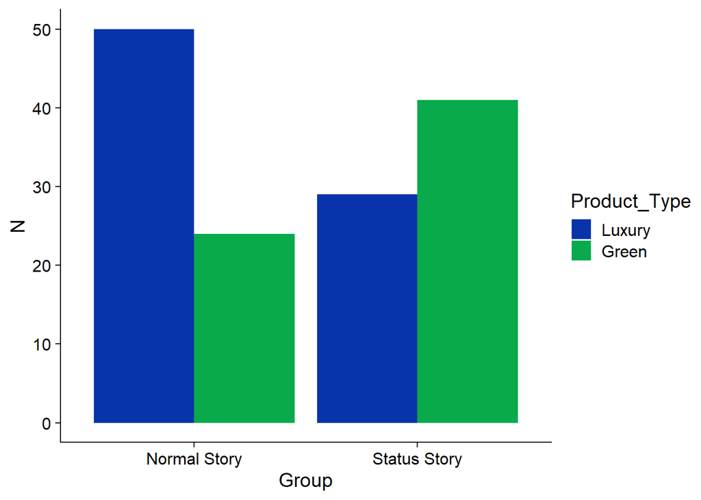

*Figure 1*: Choice of Dishwasher Type by Condition

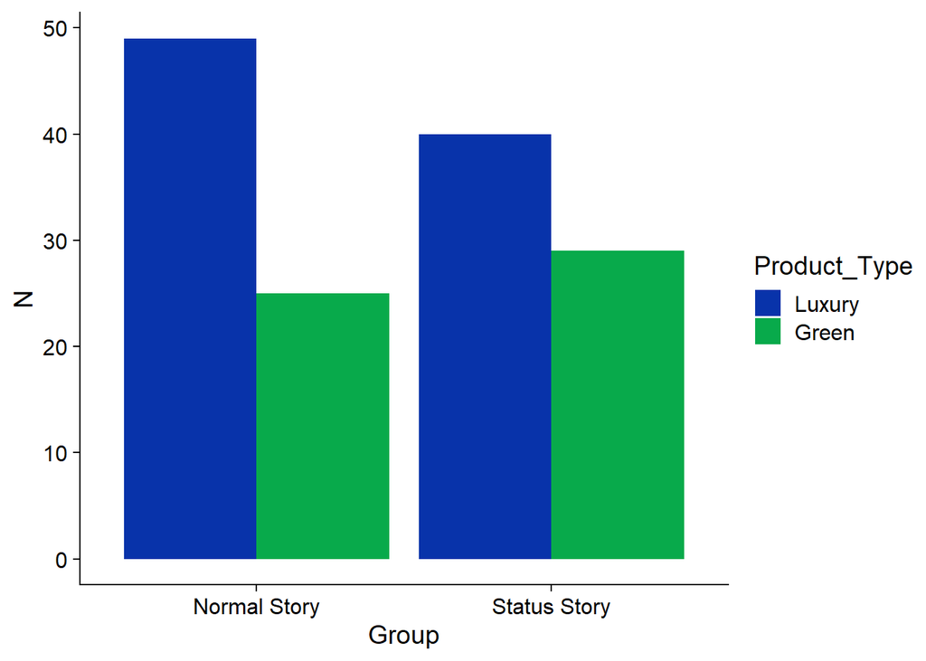

*Figure 2*: Choice of Cleaner Type by Condition

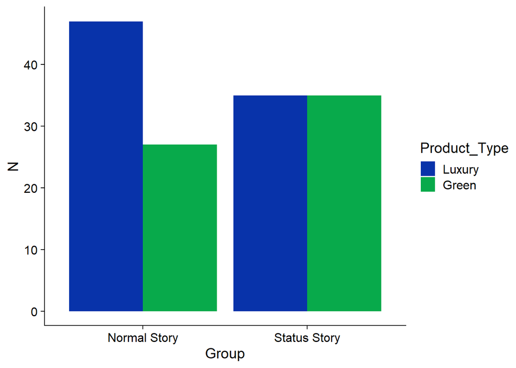

*Figure 3*: Choice of Car Type by Condition

An analysis was also performed on the effect of gender on product choice. It was found that females were more likely to choose the Luxury product than the Green product. The results of this are shown in Table 3.

*Table 3*: Choice of Product Type by Gender

|  | Male | Female |
| --- | --- | --- |
| Luxury | 103 | 112 |
| Green | 89 | 59 |

In order to determine whether the effect of the status prime was significant a Chi-squared analysis was performed. There was a significant result for the association between participants choice of the Luxury or Green products and whether they were read the Status Story or the Control Story: *X*<sup>2</sup>(1) = 10.67, *p* = 0.001. This suggests that status primes such as reading a story designed to elicit status motives can influence someone to buy Green over Luxury products, so status does influence buying choices. An analysis was also performed on the association between gender and product choice, which was also found to be significant: *X*<sup>2</sup>(1) = 4.78, *p* = 0.029. [^1] This suggests that females may be more likely to buy Luxury products over Green products than males.

# Discussion

This study was a replication of Griskevicius et al., (2010) who also found that status had a significant effect on the participants’ product choice. This suggests that people can be influenced by status to buy more environmentally friendly products.  
Similar results have been found in a field study on shoppers behaviours as it was shown that 21% of people who shopped at a “higher status” green chain in the Netherlands brought new branded bags from this chain compared to 2% of those who shopped at a “lower status” green chain. Those shopping at the “high status” chain were also less likely to use other types of reusable bags than those shopping at the “low status” chain, (van der Wal et al., 2016). This further supports the view that status can influence people to buy environmentally friendly products.

However, there may be other reasons that may have a stronger effect on consumers choices. Dagher & Itani, (2014) found that although there was a correlation between self-image and environmental protection, there were stronger correlations between environmental protection and seriousness of environmental problems and perception of personal responsibility. This research implies that there may be other factors that may be more important in determining consumers purchases than status signalling. Ramchandani et al., (2017) also found that when participants chose between luxury sunglasses made of either recycled or non-recycled wood those who chose the recycled wood sunglasses were actually less status oriented than those who chose the non-recycled sunglasses. Further research needs to be conducted in order to conclude how much of an impact status has on consumer behaviour in relation to other factors.

Although the results of the experiment proved significant there are some issues that prevent it from being entirely useful to explain this effect. One significant weakness is that the participants were all aged from 18 to 26, meaning that these effects cannot be generalised to other age groups where there may be differences in how they respond to status when buying products. Park & Park, (2012) found in their study of 554 women aged 20 to 50 that people in their 20s showed the highest amount of conspicuous consumption and fashion involvement of all the age groups. Therefore, although the results of this experiment may be significant for the age group studied if it was conducted on older participants the effects may not be seen so clearly. Another potential issue affecting the effect of this research is the context in which the readers of the status story were asked to imagine themselves in. In the status story (used in Griskevicius et al’s (2010) study) the participants are asked to imagine “moving up in status relative to his or her same-sex peers” (Griskevicius et al., 2010, p. 395). This means that participants who read the status story were possibly only thinking about how to improve their status compared to their peers, whereas it has been argued by Anderson et al., (2015) that status is “defined with reference to a particular relationship or group” (p. 2). If this is the case then it could be that participants in the Status group were more likely to buy the green products in order to elevate their status in comparison to their peers rather than it being a general effect. Another issue that could reduce the likelihood of the effect is that participants were asked to choose products rather than to actually purchase the products. Outside the context of an experiment there may be many other factors besides status that would influence participants’ buying choice such as price, convenience of purchasing the product, availability of the product etc.. So, it could be argued although the effect was significant in this experiment and participants were likely to be influenced by status, in a situation where they would be actually purchasing the product status may have little to no effect. A final weakness of this research is that there were only three products investigated (being a car, a cleaner and a washing machine) and there were differences in how status affected the choice of luxury or green types for each of these products. Therefore, although we found a significant effect for status in this study the same may not be seen if other products in a different study were to be used, once again influencing the generalisability of the results.

However, despite these potential weaknesses of the experiment the results obtained were significant and suggest that status does have an effect on consumers choice of products and behaviours (which has been supported by other research) as well as suggesting other intriguing avenues for research. This research could be used to address some of the issues in this research or to expand on the findings. For example, would the effects of status be more apparent if participants were primed to think about people who were not their peers or who they saw as being higher or lower in status as them in some way. Another potential direction for research could focus more on how much status one can gain from buying a certain green product over another, i.e. does buying a green car give you more status than buying a green cleaner. Finally, are people prepared to buy green products to improve their status even if the products cost more, are harder to find or buy etc. and how much more are they willing to pay or how much harder are they willing to try to obtain these products in order to gain status.

Overall, this research indicates that there is a relationship between status and people buying green products. There are some issues with this piece of research however that mean that the results should be taken with caution, but it does also point to many other interesting routes that investigations into this phenomenon could be taken.

# References

Anderson, C., Hildreth, J. A. D., & Howland, L. (2015). Is the desire for status a fundamental human motive? A review of the empirical literature. *Psychological Bulletin, 141*(3), 574–601.

Arianne J. van der Wal, Femke van Horen, & Amir Grinstein. (2016). The paradox of ‘green to be seen’: Green high-status shoppers excessively use (branded) shopping bags. *International Journal of Research in Marketing, 33* (1), 216–219.

Dagher, G. K., & Itani, O. (2014). Factors influencing green purchasing behaviour: Empirical evidence from the Lebanese consumers: Lebanese consumers’ green purchasing behaviour. *Journal of Consumer Behaviour, 13* (3), 188–195.

Griskevicius, V., Tybur, J. M., & Van den Bergh, B. (2010). Going Green to Be Seen: Status, Reputation, and Conspicuous Conservation. *Journal of Personality, 98*(3), 392–404.

Park, H. - J, & Park S. - H. (2012). The Effects of Conspicuous Consumption Tendency on Fashion Involvement by Age Groups. *Journal of the Korean Society for Clothing Industry, 14*(1), 56–63.

Ramchandani, M., van Holt, J., & Ivan, C.-M. (2017). What drives sustainable luxury consumption in a status driven society like India? *Journal of Textile Engineering & Fashion Technology, 2*(4), 424–427.

[^1]: This was not grouped by condition or product